# Analysis in Python

# 1 Learning Objectives

- Understand what the `pandas` and `numpy` libraries do
- Be able to do basic data manipulation in Python
- Be able to create a range of plots using both matplotlib and Seaborn

**Lesson Duration: 3 hours**

# 2 Creating data frames

`pandas` is an open source, BSD-licensed (i.e. open source) library providing high-performance, easy-to-use data structures and data analysis tools for the Python programming language. It’s similar in motivations and uses to the `dplyr` library in R.

The best way to learn `pandas` is just to get started using it! Let’s create a new notebook, and name it `intro_to_dataframes`.

Conventionally `Pandas` is imported as follows:

```python
import pandas as pd
```

The use of `pd` to indicate the `pandas` library is widespread: you should adopt this in your code too unless there is a compelling reason not to.

It is easy to manually generate an ad-hoc dataframe, let’s do it now:

```python
instructors_dataframe = pd.DataFrame({
    'name': ["Del", "Aileen", "Mhairi", "Zsolt"],
    'cohort': ["DE2", "DE2", "DE2", "E36"],
    'favourite_number': [7, 12, 3, 9]},
    index = [1,2,3,4])

instructors_dataframe
```

```
##      name cohort  favourite_number
## 1     Del    DE2                 7
## 2  Aileen    DE2                12
## 3  Mhairi    DE2                 3
## 4   Zsolt    E36                 9
```

- Note that if you don’t specify the index, then it will be automatically set as integers, starting from 0 (remember that Python is 0-indexed).

Note that when you use a function from `pandas` you have to specify `pd` before the name, as in `pd.DataFrame()`. This is similar to how you unambiguously specify a function in R, for example `package::function()`. However, you **must** do this in Python and import the library as well. This is why we renamed `pandas` as `pd`: so we don’t have to type `pandas.DataFrame()` every time!

As a next step, let’s type in a new dataframe manually (don’t worry, it’ll be a small one!)

```python
finals_score_dataframe = pd.DataFrame({
     'class1': [88, 90, 67],
     'class2':[76, 80, 83],
     'class3': [56, 91, 99]
     })
finals_score_dataframe
```

```
##    class1  class2  class3
## 0      88      76      56
## 1      90      80      91
## 2      67      83      99
```

Let’s take a look at a couple of methods that can help us find out more about our dataframe!

If we want to get sets of the first or last values, we can use the `head()` or `tail()` functions. The default number of rows printed by these functions is always 5, unless we specify it with an argument:

```python
finals_score_dataframe.head()
# or
```

```
##    class1  class2  class3
## 0      88      76      56
## 1      90      80      91
## 2      67      83      99
```

```python
finals_score_dataframe.tail()
# or get the last row
```

```
##    class1  class2  class3
## 0      88      76      56
## 1      90      80      91
## 2      67      83      99
```

```python
finals_score_dataframe.tail(1)
```

```
##    class1  class2  class3
## 2      67      83      99
```

We can see the dimensions by accessing the `shape` **property** (note that this is not a method - do not call it with the brackets, you’ll get an error)

```python
finals_score_dataframe.shape
```

```
## (3, 3)
```

To check the column names, you can check them with the `columns` property (as above: this is a property not a method)

```python
finals_score_dataframe.columns
```

```
## Index(['class1', 'class2', 'class3'], dtype='object')
```

We can see a summarised list of details of a dataframe using the `.describe()` method:

```python
finals_score_dataframe.describe()
```

```
##           class1     class2     class3
## count   3.000000   3.000000   3.000000
## mean   81.666667  79.666667  82.000000
## std    12.741010   3.511885  22.869193
## min    67.000000  76.000000  56.000000
## 25%    77.500000  78.000000  73.500000
## 50%    88.000000  80.000000  91.000000
## 75%    89.000000  81.500000  95.000000
## max    90.000000  83.000000  99.000000
```

> Take a moment to look at the output of the `describe()` method. Are you clear what all of the entries correspond to?

> **Solution**

> We have the count of entries, mean, standard deviation, minimum, maximum and 25%, 50% (median) and 75% quartiles

We can also access the variances via the `var()` method:

```python
finals_score_dataframe.var()
```

```
## class1    162.333333
## class2     12.333333
## class3    523.000000
## dtype: float64
```

Now, how we can add more columns, and set/reset the indexes?

- First, let’s get the values for the new column we want to add.
- Then assign these values to a new column name.
- Finally we can set it as an index if we so desire!

```python
names = ["Alice", "Bob", "Carmen"]
finals_score_dataframe["Name"] = names
finals_score_dataframe.set_index('Name')
```

```
##         class1  class2  class3
## Name
## Alice       88      76      56
## Bob         90      80      91
## Carmen      67      83      99
```

> **Task - 5 minutes**
> - Search online for how to reset the index in a `pandas` dataframe.
> - What happens to the old index?

> **Solution**

> ```python
> finals_score_dataframe.reset_index()
> ```

> ```
> ##    index  class1  class2  class3    Name
> ## 0      0      88      76      56   Alice
> ## 1      1      90      80      91     Bob
> ## 2      2      67      83      99  Carmen
> ```

> The old index will be added as a regular column.

> **Task - 5 minutes**
> 1. Turn this small table into a data frame called ‘shoe_satisfaction’.

> | age | gender | shoe_size | is_satisfied |
> | --- | --- | --- | --- |
> | 25 | female | 7 | TRUE |
> | 56 | female | 5 | TRUE |
> | 40 | male | 13 | FALSE |

> 2. Run or access the following on the data frame:
> 1. `head()`
> 2. `describe()`
> 3. `shape`
> 3. Add another column to the data frame called `price` containing the following data: 33.50, 15.99, 39.99.

> **Solution**

> ```python
> shoe_satisfaction = pd.DataFrame({
>   "age"          : [25, 56, 40],
>   "gender"       : ["female", "female", "male"],
>   "shoe_size"    : [7, 5, 13],
>   "is_satisfied" : [True, True, False]
> })
> ```

> ```python
> shoe_satisfaction.head()
> ```

> ```
> ##    age  gender  shoe_size  is_satisfied
> ## 0   25  female          7          True
> ## 1   56  female          5          True
> ## 2   40    male         13         False
> ```

> ```python
> shoe_satisfaction.describe()
> ```

> ```
> ##              age  shoe_size
> ## count   3.000000   3.000000
> ## mean   40.333333   8.333333
> ## std    15.502688   4.163332
> ## min    25.000000   5.000000
> ## 25%    32.500000   6.000000
> ## 50%    40.000000   7.000000
> ## 75%    48.000000  10.000000
> ## max    56.000000  13.000000
> ```

> ```python
> shoe_satisfaction.shape
> ```

> ```
> ## (3, 4)
> ```

> ```python
> shoe_satisfaction["price"] = [33.50, 15.99, 39.99]
> ```

# 3 Using `numpy`

In R, all common statistical functions are part of the base language. However, in Python, we need to use another library to make these calculations straightforward.

To apply an out of the box `mean()` method to our numbers, we should become acquainted with `numpy`. It is a package used for scientific computing (‘NUMerical PYthon’), and comes with quite a few useful methods out of the box, especially when it comes to handling matrices.

We can import it as follows:

```python
import numpy as np
```

Let’s use `numpy`’s own mean method. Here’s how we use it on a column of a data frame:

```python
np.mean(finals_score_dataframe['class1'])
```

```
## 81.66666666666667
```

We can also use the `apply()` method of a data frame to calculate the mean of every column. We’ll need to make ‘Name’ an index again, since we don’t want to calculate the mean of it.

```python
finals_score_dataframe = finals_score_dataframe.set_index("Name")
```

Notice we will not calling the method with the brackets - we are passing in the function name, and letting the `apply()` method call it for us.

```python
finals_score_dataframe.apply(np.mean, axis = 0)
```

```
## class1    81.666667
## class2    79.666667
## class3    82.000000
## dtype: float64
```

```python
finals_score_dataframe.apply(np.mean, axis = 1)
```

```
## Name
## Alice     73.333333
## Bob       87.000000
## Carmen    83.000000
## dtype: float64
```

Note the difference that `axis = 0` applies the method vertically over columns, while `axis = 1` applies it horizontally across rows.

# 4 Verbs in `pandas`.

Now we’ll see how to use the equivalent of the five `dplyr` verbs in `pandas`, along with reading in a CSV file using a more helpful function.

First, we import `pandas` and read in the CSV file:

```python
import pandas as pd
prestige_dataframe = pd.read_csv("prestige_occupation.csv")
prestige_dataframe
```

```
##                      job  education  income  women  prestige  census  type
## 0     gov.administrators      13.11   12351  11.16      68.8    1113  prof
## 1       general.managers      12.26   25879   4.02      69.1    1130  prof
## 2            accountants      12.77    9271  15.70      63.4    1171  prof
## 3    purchasing.officers      11.42    8865   9.11      56.8    1175  prof
## 4               chemists      14.62    8403  11.68      73.5    2111  prof
## ..                   ...        ...     ...    ...       ...     ...   ...
## 97           bus.drivers       7.58    5562   9.47      35.9    9171    bc
## 98          taxi.drivers       7.93    4224   3.59      25.1    9173    bc
## 99          longshoremen       8.37    4753   0.00      26.1    9313    bc
## 100          typesetters      10.00    6462  13.58      42.2    9511    bc
## 101          bookbinders       8.55    3617  70.87      35.2    9517    bc
##
## [102 rows x 7 columns]
```

Here we see our data along with a helpful statement of the number of rows and columns at the bottom.

> **Task - 5 mins**

> In using the `pandas` `read_csv()` function here we have a rather simple call, but we’re relying on a large number of default parameters being set. Search online for the docs for this function and have a look at the available parameters.

Now we can start working with our data.

## 4.1 Select

Subsetting data is fairly easy: using the square bracket notation, we can display one, or more columns.

```python
prestige_dataframe["income"]
```

```
## 0      12351
## 1      25879
## 2       9271
## 3       8865
## 4       8403
##        ...
## 97      5562
## 98      4224
## 99      4753
## 100     6462
## 101     3617
## Name: income, Length: 102, dtype: int64
```

```python
prestige_dataframe[["income", "prestige"]]
```

```
##      income  prestige
## 0     12351      68.8
## 1     25879      69.1
## 2      9271      63.4
## 3      8865      56.8
## 4      8403      73.5
## ..      ...       ...
## 97     5562      35.9
## 98     4224      25.1
## 99     4753      26.1
## 100    6462      42.2
## 101    3617      35.2
##
## [102 rows x 2 columns]
```

> Note that when you want to display more than one columns, you have to pass in a `list` within the square brackets.

We can save the result of this into a new data frame if we want to.

```python
income_and_prestige = prestige_dataframe[["income", "prestige"]]
```

```python
prestige_dataframe.rename(columns={"job":"job_title"})
```

```
##                job_title  education  income  women  prestige  census  type
## 0     gov.administrators      13.11   12351  11.16      68.8    1113  prof
## 1       general.managers      12.26   25879   4.02      69.1    1130  prof
## 2            accountants      12.77    9271  15.70      63.4    1171  prof
## 3    purchasing.officers      11.42    8865   9.11      56.8    1175  prof
## 4               chemists      14.62    8403  11.68      73.5    2111  prof
## ..                   ...        ...     ...    ...       ...     ...   ...
## 97           bus.drivers       7.58    5562   9.47      35.9    9171    bc
## 98          taxi.drivers       7.93    4224   3.59      25.1    9173    bc
## 99          longshoremen       8.37    4753   0.00      26.1    9313    bc
## 100          typesetters      10.00    6462  13.58      42.2    9511    bc
## 101          bookbinders       8.55    3617  70.87      35.2    9517    bc
##
## [102 rows x 7 columns]
```

This is a good place to mention the ‘inplace’ behaviour of `pandas`. By default, changes that mutate a data frame tend to be returned by `pandas` but not persisted. We can see this above, where it looks as if column `job` has indeed been renamed to `job_title`, but let’s look again at the data frame

```python
prestige_dataframe.head()
```

```
##                    job  education  income  women  prestige  census  type
## 0   gov.administrators      13.11   12351  11.16      68.8    1113  prof
## 1     general.managers      12.26   25879   4.02      69.1    1130  prof
## 2          accountants      12.77    9271  15.70      63.4    1171  prof
## 3  purchasing.officers      11.42    8865   9.11      56.8    1175  prof
## 4             chemists      14.62    8403  11.68      73.5    2111  prof
```

Hmm, we’re back to `job`. To persist the change, we either need to overwrite the data frame, as we saw earlier, or we can use the `inplace = True` argument

```python
prestige_dataframe.rename(columns={"job":"job_title"}, inplace = True)
prestige_dataframe.head()
```

```
##              job_title  education  income  women  prestige  census  type
## 0   gov.administrators      13.11   12351  11.16      68.8    1113  prof
## 1     general.managers      12.26   25879   4.02      69.1    1130  prof
## 2          accountants      12.77    9271  15.70      63.4    1171  prof
## 3  purchasing.officers      11.42    8865   9.11      56.8    1175  prof
## 4             chemists      14.62    8403  11.68      73.5    2111  prof
```

## 4.2 Arrange

You can sort data with the `sort_values()` method

```python
prestige_dataframe.sort_values("prestige", ascending = False)
```

```
##               job_title  education  income  women  prestige  census  type
## 23           physicians      15.96   25308  10.56      87.2    3111  prof
## 20  university.teachers      15.97   12480  19.59      84.6    2711  prof
## 16              lawyers      15.77   19263   5.13      82.3    2343  prof
## 7            architects      15.44   14163   2.69      78.1    2141  prof
## 5            physicists      15.64   11030   5.13      77.6    2113  prof
## ..                  ...        ...     ...    ...       ...     ...   ...
## 63           launderers       7.33    3000  69.31      20.8    6162    bc
## 60           bartenders       8.50    3930  15.51      20.2    6123    bc
## 65   elevator.operators       7.58    3582  30.08      20.1    6193    bc
## 64             janitors       7.11    3472  33.57      17.3    6191    bc
## 52             newsboys       9.62     918   7.00      14.8    5143   NaN
##
## [102 rows x 7 columns]
```

By default it is going to be in an ascending order, where `NaN` values are placed at the end.

## 4.3 Filter

If I want to select all the rows where the `type` is ‘bc’, we can do it as follows:

First we need to check for the rows with the `type` ‘bc’:

```python
prestige_dataframe["type"] == "bc"
```

```
## 0      False
## 1      False
## 2      False
## 3      False
## 4      False
##        ...
## 97      True
## 98      True
## 99      True
## 100     True
## 101     True
## Name: type, Length: 102, dtype: bool
```

Using this, we can filter out the rows we need easily:

```python
blue_collar_prestige_dataframe = prestige_dataframe[prestige_dataframe["type"] == "bc"]
blue_collar_prestige_dataframe
```

```
##                      job_title  education  income  women  prestige  census type
## 27               nursing.aides       9.45    3485  76.14      34.9    3135   bc
## 53   service.station.attendant       9.93    2370   3.69      23.3    5145   bc
## 57                firefighters       9.47    8895   0.00      43.5    6111   bc
## 58                   policemen      10.93    8891   1.65      51.6    6112   bc
## 59                       cooks       7.74    3116  52.00      29.7    6121   bc
## 60                  bartenders       8.50    3930  15.51      20.2    6123   bc
## 61           funeral.directors      10.57    7869   6.01      54.9    6141   bc
## 63                  launderers       7.33    3000  69.31      20.8    6162   bc
## 64                    janitors       7.11    3472  33.57      17.3    6191   bc
## 65          elevator.operators       7.58    3582  30.08      20.1    6193   bc
## 67                farm.workers       8.60    1656  27.75      21.5    7182   bc
## 68        rotary.well.drillers       8.88    6860   0.00      35.3    7711   bc
## 69                      bakers       7.54    4199  33.30      38.9    8213   bc
## 70              slaughterers.1       7.64    5134  17.26      25.2    8215   bc
```

[output cut: 30 more lines]

Python will look through our the logical list set up by `prestige_dataframe["type"] == "bc"`, and wherever it finds a `True` value, that row of the whole data frame will be included.

## 4.4 Mutate

We’ve already seen how to create new columns. You can use the same method to change an existing column.

```python
prestige_dataframe['income'] = prestige_dataframe['income']/1000
prestige_dataframe.head()
```

```
##              job_title  education  income  women  prestige  census  type
## 0   gov.administrators      13.11  12.351  11.16      68.8    1113  prof
## 1     general.managers      12.26  25.879   4.02      69.1    1130  prof
## 2          accountants      12.77   9.271  15.70      63.4    1171  prof
## 3  purchasing.officers      11.42   8.865   9.11      56.8    1175  prof
## 4             chemists      14.62   8.403  11.68      73.5    2111  prof
```

## 4.5 Group by and summarise

Grouping data can be done with the `groupby()` method, and then we can chain other methods to it, like `min()`, `max()`, or `mean()` to get more insight. Note however that if we don’t call a summarising method at the end of the chain, `pandas` will not return us a new dataframe, but a `groupby` object. This is an example of what is called **lazy evaluation** - Python will try to defer ‘concretising’ data for as long as possible, because there is no point concretising data until it is actually needed, particularly when later operations may filter out rows or columns. The `magrittr` pipes in R perform a similar function.

```python
prestige_dataframe.groupby('type')['income'].max()
```

```
## type
## bc       8.895
## prof    25.879
## wc       8.780
## Name: income, dtype: float64
```

```python
prestige_dataframe.groupby('type').describe()
```

```
##      education                              ...   census
##          count       mean       std    min  ...      25%     50%      75%     max
## type                                        ...
## bc        44.0   8.359318  1.164834   6.38  ...  7578.75  8424.0  8780.25  9517.0
## prof      31.0  14.084194  1.394025  11.09  ...  2142.00  2331.0  2922.00  9111.0
## wc        23.0  11.021739  0.923308   9.17  ...  4138.00  4173.0  4663.50  5191.0
##
## [3 rows x 40 columns]
```

In the case that you want to return an entire row with specific conditions, you can use `loc()`:

```python
lowest_prestige_index = prestige_dataframe['prestige'].idxmin()
prestige_dataframe.loc[lowest_prestige_index]
```

```
## job_title    newsboys
## education        9.62
## income          0.918
## women               7
## prestige         14.8
## census           5143
## type              NaN
## Name: 52, dtype: object
```

`idxmin()` returns the index of the row with the lowest value, and we then pass that in to `loc()` to pull out that whole row. Similarly, `idxmax()` returns the index of the row with the highest value.

> **Task - 5 minutes**

> Return 2 rows at the same time, with the highest and lowest income!

> [**Hint** - you can pass a list as an argument for `loc()`]

> **Solution**

> ```python
> lowest_income_index = prestige_dataframe["income"].idxmin()
> highest_income_index = prestige_dataframe["income"].idxmax()
> prestige_dataframe.loc[[lowest_income_index, highest_income_index]]
> ```

> ```
> ##            job_title  education  income  women  prestige  census  type
> ## 62       babysitters       9.46   0.611  96.53      25.9    6147   NaN
> ## 1   general.managers      12.26  25.879   4.02      69.1    1130  prof
> ```

## 4.6 Missing values

What happens if some of the values are not available (NA) in a data frame? With Python, we can represent missing values with numpy’s `nan` value:

```python
finals_score_dataframe = pd.DataFrame({
     'class1': [88, np.nan, 67],
     'class2':[76, 80, 83],
     'class3': [np.nan, 91, 99]
     })
```

The same thing happens if we read in a CSV file with missing values: `pandas` will automatically detect and assign `nan` values to all missing data.

In R, if you try to calculate the mean of a column that contains a missing value the answer will be a missing value. However, in Python the same behaviour you see when you set `na.rm = TRUE` happens by default.

```python
finals_score_dataframe.apply(np.mean, axis = 0)
```

```
## class1    77.500000
## class2    79.666667
## class3    95.000000
## dtype: float64
```

If you you want to substitute for the missing values, you can do so by using the `fillna()` method:

```python
finals_score_dataframe.fillna(0)
```

```
##    class1  class2  class3
## 0    88.0      76     0.0
## 1     0.0      80    91.0
## 2    67.0      83    99.0
```

Note that, as earlier, to persist any changes you either have to save the return value of `fillna()` to a new variable, or you have to set the `inplace = True`, which forces in-place modification:

```python
finals_score_dataframe.fillna(0, inplace = True)
```

One of the tricky parts of learning `pandas` is knowing which functions return a value and which change the data frame in-place. In R all functions return a value.

> **Task - 5 minutes**

> Find out how you can change `nan` values in different columns to different values - [Link to fillna() documentation](https://pandas.pydata.org/pandas-docs/stable/reference/api/pandas.DataFrame.fillna.html)

> Change the missing values in class 1 to 100; class 2 to 0; and class 3 to 50.

> ```python
> import numpy as np
> finals_score_dataframe = pd.DataFrame({
>      'class1': [88, np.nan, 67],
>      'class2':[np.nan, 80, 83],
>      'class3': [np.nan, 91, 99]
>      })
> ```

> **Solution**

> For our `fillna()` method, we can pass in a `dict` in which keys are column names, and values are the `nan` substitutions for each column.

> Here we persist the changes by reassignment.

> ```python
> finals_score_dataframe = finals_score_dataframe.fillna({"class1": 100, "class2": 0, "class3": 50})
> finals_score_dataframe
> ```

> ```
> ##    class1  class2  class3
> ## 0    88.0     0.0    50.0
> ## 1   100.0    80.0    91.0
> ## 2    67.0    83.0    99.0
> ```

### 4.6.1 Prestige data

Let’s use the `describe()` method to summarise the details of our dataframe:

```python
prestige_dataframe.shape
```

```
## (102, 7)
```

```python
prestige_dataframe.describe(include = 'all')
```

```
##            job_title   education      income  ...    prestige       census  type
## count            102  102.000000  102.000000  ...  102.000000   102.000000    98
## unique           102         NaN         NaN  ...         NaN          NaN     3
## top     longshoremen         NaN         NaN  ...         NaN          NaN    bc
## freq               1         NaN         NaN  ...         NaN          NaN    44
## mean             NaN   10.738039    6.797902  ...   46.833333  5401.774510   NaN
## std              NaN    2.728444    4.245922  ...   17.204486  2644.993215   NaN
## min              NaN    6.380000    0.611000  ...   14.800000  1113.000000   NaN
## 25%              NaN    8.445000    4.106000  ...   35.225000  3120.500000   NaN
## 50%              NaN   10.540000    5.930500  ...   43.600000  5135.000000   NaN
## 75%              NaN   12.647500    8.187250  ...   59.275000  8312.500000   NaN
## max              NaN   15.970000   25.879000  ...   87.200000  9517.000000   NaN
##
## [11 rows x 7 columns]
```

Flag `include = 'all'` tells `describe()` to include all columns and not just those containing numeric data. If we look in detail, we see a discrepancy in the counts of values, in that `type` has fewer values than the other columns. This means that the `type` column probably has missing data.

After `pandas` reads in the data, the missing values will be described as `NaN`. We can count how many of these there are by using the combination of `.isna()` (or `isnull()`) and `.sum()` methods:

```python
prestige_dataframe.isnull().sum()
```

```
## job_title    0
## education    0
## income       0
## women        0
## prestige     0
## census       0
## type         4
## dtype: int64
```

This gives us the exact number of cells where we have no values added.

You can drop rows with `nan` values using the `.dropna()` method:

```python
prestige_dataframe.dropna(inplace = True)
```

This covers just the basics of dealing with missing data in Python, `pandas` offers many more possibilities.

# 5 Plotting with matplotlib/Seaborn

Python has a wide range of tools that lets you create graphs and plots. These libraries are pretty different from `ggplot2`. First let’s look at the `matplotlib` library which integrates with `pandas`.

Let’s import it (again, we stick to the common naming convention)!

```python
import matplotlib as plt
```

To see the plots in your Jupyter notebook, you’ll need to use a special command at the start of the notebook.

```
%matplotlib inline
```

This special syntax with `%` is a Jupyter notebook magic command. These are commands that change how Jupyter notebooks interprets your code. In this case it insures that plots appear in the notebook.

Creating a plot is fairly straightforward. You have to call the `plot()` method on the data frame you want to use (be aware that you can use subsets of your dataframe if required). We pass in an argument to specify the `kind` of plot.

An example of a histogram using the `income` data:

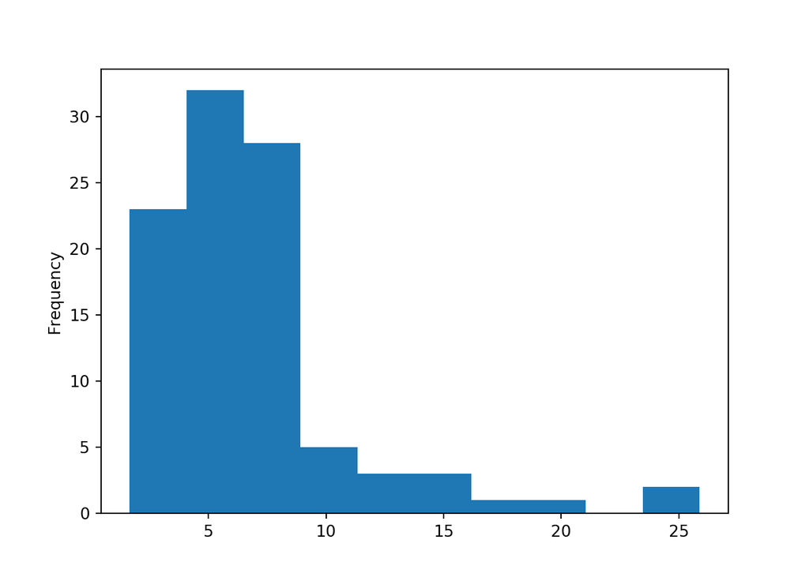

```python
prestige_dataframe["income"].plot(kind = "hist")
```

Boxplot using the `education` data:

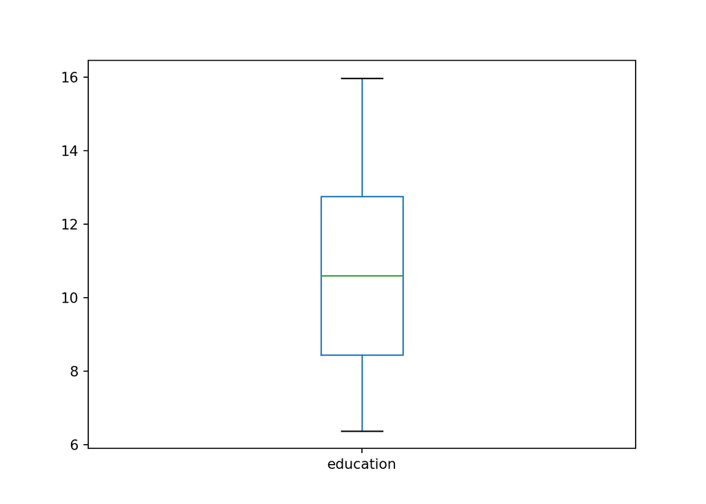

```python
prestige_dataframe["education"].plot(kind = "box")
```

Scatterplot using `education` and `prestige`, coloured by `income`:

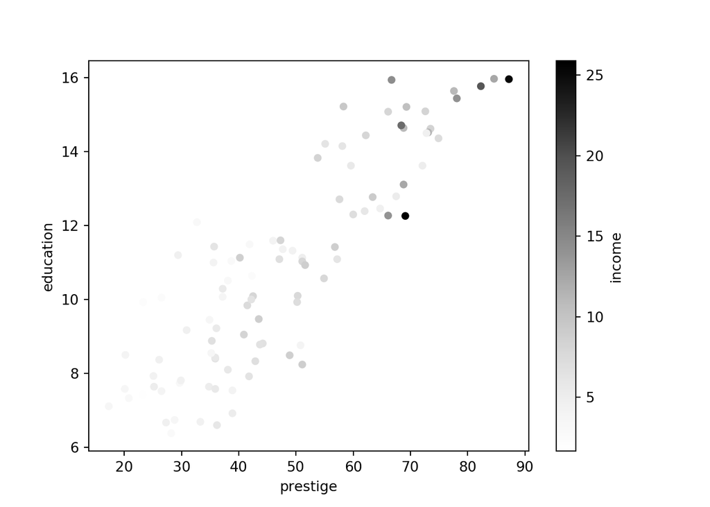

```python
prestige_dataframe.plot(kind = "scatter", x = "prestige", y = "education", c = "income")
```

These plots do the job well enough, and are fine for day-to-day analysis tasks. However, if we want more polished looking plots, we might want to consider using the `seaborn` library! First, we need to import it, conventionally as `sns`:

```python
import seaborn as sns
```

Second, we have to know how `seaborn` handles different types of plots. If we want to create a histogram, we can use the `distplot()` method in `sns`:

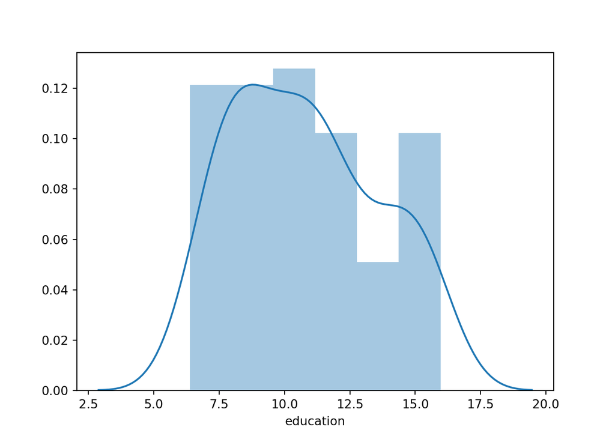

```python
sns.distplot(prestige_dataframe['education'])
```

Note that Seaborn does not work well with `nan` values - we have to change them before we can create a histogram.

Creating a box plot can be done similarly:

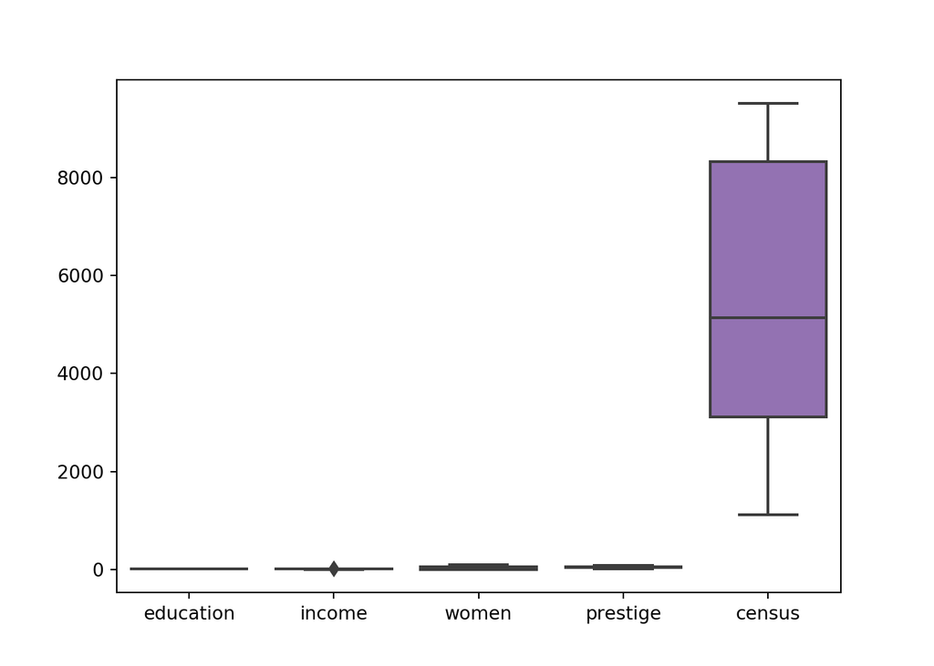

```python
sns.boxplot(data=prestige_dataframe)
```

Scatter plots created with the `regplot()` method are also much prettier than the base `matplotlib` equivalent:

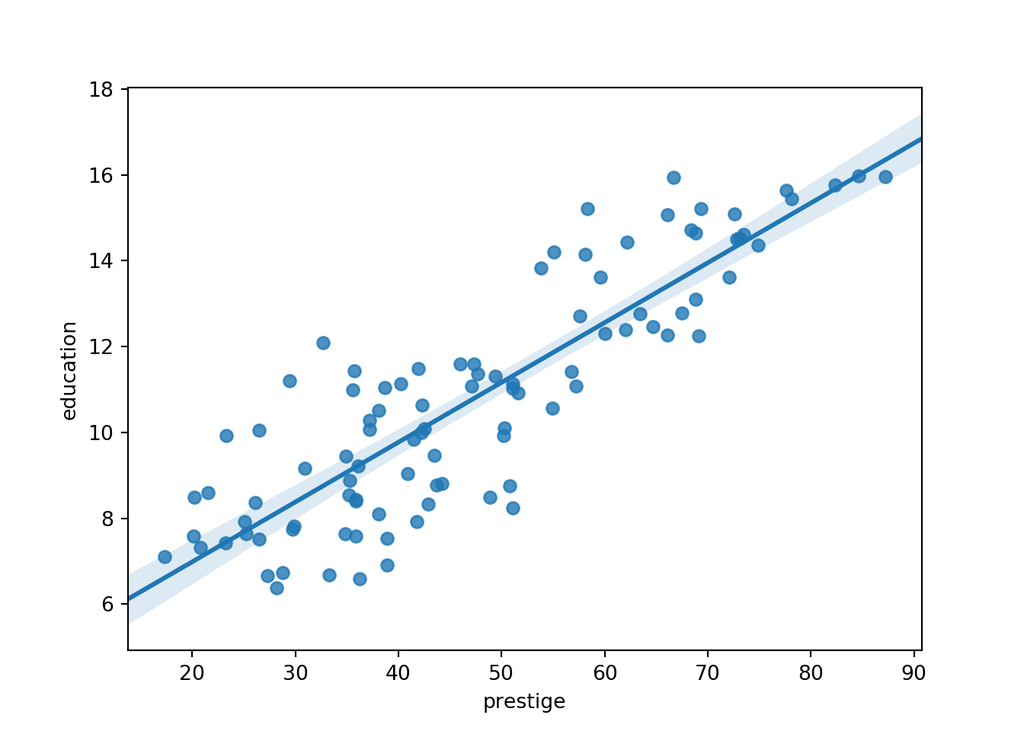

```python
sns.regplot(x='prestige', y='education', data=prestige_dataframe)
```

Refer to the documentation for more customisation options and the different argument types. Libraries have different levels of quality when it comes to documentation, but generally speaking, open source Python libraries are well documented, and you can always contribute to them if you feel that there is room for improvement.